# HW5 - King County Real Estate Assignment

Jeff Smith

This homework involves two problems – both based on a real estate dataset similar (but not identical) the Auburn dataset that we used in class.

You are planning a move to Seattle and are hoping to buy a house/condo/townhouse with your new-found wealth from your signing bonus with Amazon. For the first problem, using the provided King County real estate transaction information, conduct an Exploratory Data Analysis with the primary objective of collecting information for your future purchase. The data are similar, but not identical to the Auburn real estate data that we used in class, so you should definitely explore the additional columns and look for meaningful relationships in the data. The script file that we used with the Auburn data in class should be of significant help to you.

In addition to the analysis/plots that you generate, be sure to use markdown sections of this notebook to describe your findings and discuss “what the data tells you.” Feel free to make comparisons to the Auburn market if you find that informative. Note that this assignment is more than just generating random plots. EDA is a process where you explore the data to find useful information and meaningful relationships in the data. This analysis should include the use of tools from the Data Transformation chapter (filtering, sorting, mutating, grouping and summarizing, etc.) in addition to plots and graphs from the visualization chapter. Note that not everything that you try will provide useful information, so be sure to use markdown to explain what you find and which visualizations you find informative.

Second, use the modelr package to develop a regression-type predictive model that predicts price based on square footage (using sqft_living for the square footage). The models_example1.R script file and the corresponding class and video materials should provide a guideline for this part of the assignment. Note that you are free to use the lm or glm methods to verify your model, but I want you to replicate the basic process described in the book and the models_example.R script and associated video module.

The data file used for this assignment is from the Coursera course “Machine Learning: Regression” - https://www.coursera.org/learn/ml-regression/home/welcome

```r
library("tidyverse")
library(ggplot2)
getwd()
```

```
[1] "C:/Users/YJY/eclipse-workspace/Data-Analytics-and-Modeling/code/R"
```

```r
kcre <- read_csv("..\\..\\data\\kc_house_data.csv")
str(kcre)
```

```
spec_tbl_df [21,613 x 21] (S3: spec_tbl_df/tbl_df/tbl/data.frame)
 $ id           : num [1:21613] 7.13e+09 6.41e+09 5.63e+09 2.49e+09 1.95e+09 ...
 $ date         : POSIXct[1:21613], format: "2014-10-13" "2014-12-09" ...
 $ price        : num [1:21613] 221900 538000 180000 604000 510000 ...
 $ bedrooms     : num [1:21613] 3 3 2 4 3 4 3 3 3 3 ...
 $ bathrooms    : num [1:21613] 1 2.25 1 3 2 4.5 2.25 1.5 1 2.5 ...
 $ sqft_living  : num [1:21613] 1180 2570 770 1960 1680 ...
 $ sqft_lot     : num [1:21613] 5650 7242 10000 5000 8080 ...
 $ floors       : num [1:21613] 1 2 1 1 1 1 2 1 1 2 ...
 $ waterfront   : num [1:21613] 0 0 0 0 0 0 0 0 0 0 ...
 $ view         : num [1:21613] 0 0 0 0 0 0 0 0 0 0 ...
 $ condition    : num [1:21613] 3 3 3 5 3 3 3 3 3 3 ...
 $ grade        : num [1:21613] 7 7 6 7 8 11 7 7 7 7 ...
 $ sqft_above   : num [1:21613] 1180 2170 770 1050 1680 ...
 $ sqft_basement: num [1:21613] 0 400 0 910 0 1530 0 0 730 0 ...
 $ yr_built     : num [1:21613] 1955 1951 1933 1965 1987 ...
 $ yr_renovated : num [1:21613] 0 1991 0 0 0 ...
 $ zipcode      : num [1:21613] 98178 98125 98028 98136 98074 ...
 $ lat          : num [1:21613] 47.5 47.7 47.7 47.5 47.6 ...
 $ long         : num [1:21613] -122 -122 -122 -122 -122 ...
 $ sqft_living15: num [1:21613] 1340 1690 2720 1360 1800 ...
 $ sqft_lot15   : num [1:21613] 5650 7639 8062 5000 7503 ...
 - attr(*, "spec")=
  .. cols(
  ..   id = col_double(),
  ..   date = col_datetime(format = ""),
  ..   price = col_double(),
  ..   bedrooms = col_double(),
  ..   bathrooms = col_double(),
  ..   sqft_living = col_double(),
  ..   sqft_lot = col_double(),
  ..   floors = col_double(),
  ..   waterfront = col_double(),
  ..   view = col_double(),
  ..   condition = col_double(),
  ..   grade = col_double(),
  ..   sqft_above = col_double(),
  ..   sqft_basement = col_double(),
  ..   yr_built = col_double(),
  ..   yr_renovated = col_double(),
  ..   zipcode = col_double(),
  ..   lat = col_double(),
  ..   long = col_double(),
  ..   sqft_living15 = col_double(),
  ..   sqft_lot15 = col_double()
  .. )
 - attr(*, "problems")=<externalptr>
```

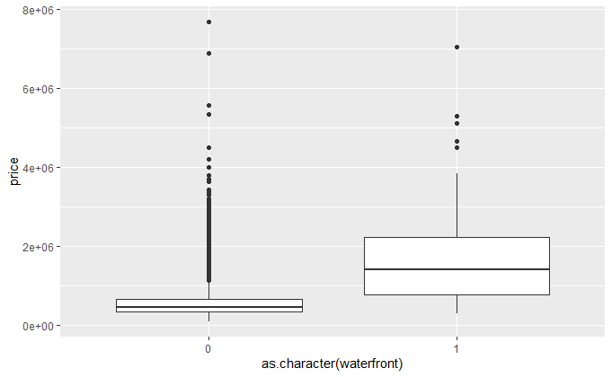

```r
# My first personal interest is the waterfront feature in purchasing a house.
ggplot(data = kcre, mapping = aes(x = as.character(waterfront), y = price)) + geom_boxplot()
```

As showing in the plot, properties with waterfront have much higher value. For money issue, I won’t consider those luxury property. And those property are treated as out-liner and filtered out at the moment.

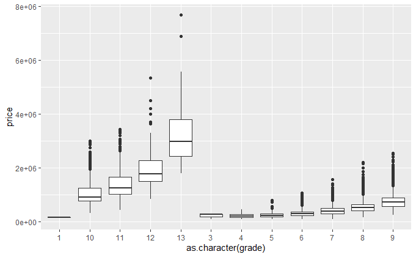

```r
# filter out those property with waterfront
mask = kcre$waterfront == 0
kcre_no_waterfront <- kcre[mask, ]

# similarly I will plot more categorical data
ggplot(data = kcre_no_waterfront, mapping = aes(x = as.character(grade), y = price)) + geom_boxplot()
```

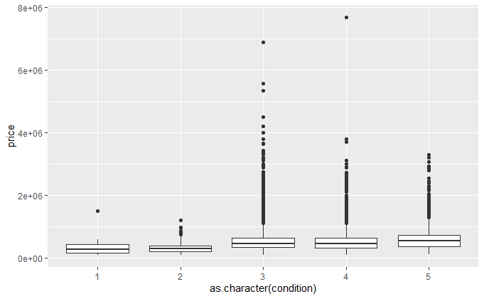

```r
ggplot(data = kcre_no_waterfront, mapping = aes(x = as.character(condition), y = price)) + geom_boxplot()
```

As the plots showing, price is positive related with grade and condition. Particularly, price is highly positive related to grade feature. It is intuitive that property square feet is positively related with price. This is the next thing I would look into.

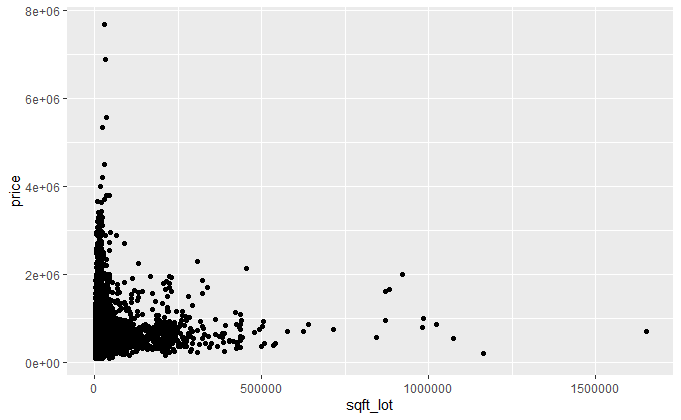

```r
# relation between sqft_lot and price
ggplot(data = kcre_no_waterfront) +
  geom_point(mapping = aes(x = sqft_lot, y = price))
```

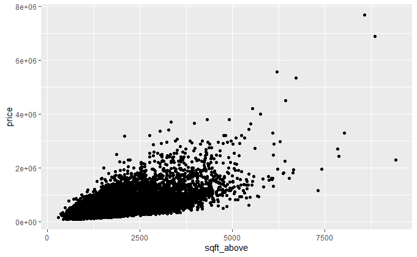

```r
# relation between sqft_above and price
ggplot(data = kcre_no_waterfront) +
  geom_point(mapping = aes(x = sqft_above, y = price))
```

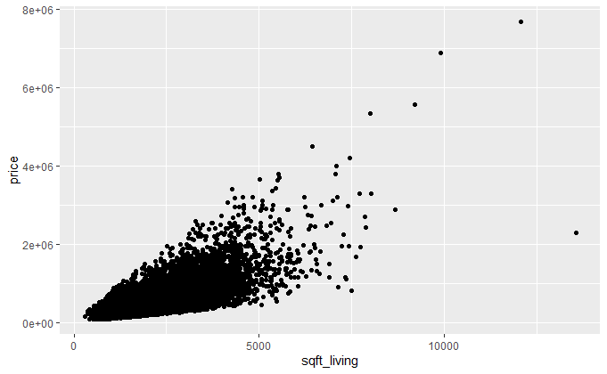

```r
# relation between sqft_above and price
ggplot(data = kcre_no_waterfront) +
  geom_point(mapping = aes(x = sqft_living, y = price))
```

Lot over price plot shows that the lot size is concentrated up to 250k sqft and there are also out-liners. Sqft_above and sqft_living plots show that there are certain linear relation between those two variable and price respectively. And this matches up with my expectation. Next, the value of a property should have some relationship with the zipcode. I want to avoid such areas that are too expensive.

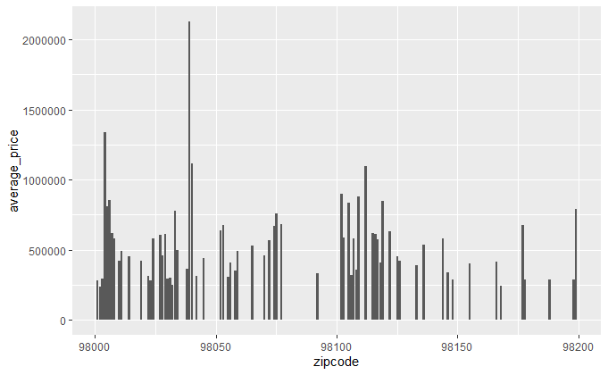

```r
# find average value in different zip
zip = unique(kcre_no_waterfront$zipcode)
zip_price_mean <- c()
for (z in zip) {
  average = mean(kcre_no_waterfront[kcre_no_waterfront$zipcode == z, ]$price)
zip_price_mean <- c(zip_price_mean, average)
}
zip_price <- data.frame(
  zipcode = zip, average_price = zip_price_mean)
#barplot(t(as.matrix(zip_price)), beside=TRUE)
ggplot(zip_price, aes(x = zipcode, y = average_price)) +
  geom_bar(stat = "identity")
```

This plot shows that the average price over different zip code. I can conclude that the price in certain areas are significantly higher than others. By searching on Google maps, Amazon office buildings are mainly located at 98101, 98109, 98121. To think of a home purchasing, I personally want my home located not too far away from my work, school and grocery. So I will take this into consideration.

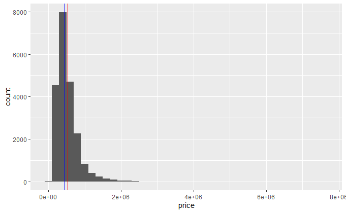

```r
# additional columns to the dataset
# each new column is the unit price
kcre_no_waterfront <- kcre_no_waterfront %>%
  mutate(
    lotPrice = kcre_no_waterfront$price / kcre_no_waterfront$sqft_lot,
    livingPrice = kcre_no_waterfront$price / kcre_no_waterfront$sqft_living,
    abovePrice = kcre_no_waterfront$price / kcre_no_waterfront$sqft_above
  )

# Property Price histogram
ggplot(data = kcre_no_waterfront) +
  geom_histogram(mapping = aes(x = price), binwidth = 200000) +
  geom_vline(xintercept=mean(kcre_no_waterfront$price), color="red") +
  geom_vline(xintercept=median(kcre_no_waterfront$price), color="blue")
```

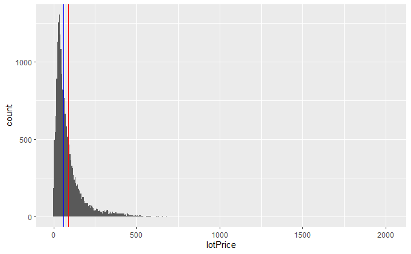

```r
# Property lot Price histogram
ggplot(data = kcre_no_waterfront) +
  geom_histogram(mapping = aes(x = lotPrice), binwidth = 5) +
  geom_vline(xintercept=mean(kcre_no_waterfront$lotPrice), color="red") +
  geom_vline(xintercept=median(kcre_no_waterfront$lotPrice), color="blue")
```

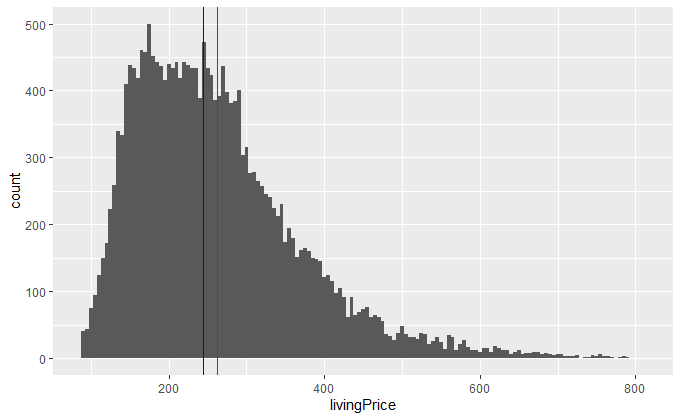

```r
# Property lot Price histogram
ggplot(data = kcre_no_waterfront) +
  geom_histogram(mapping = aes(x = livingPrice), binwidth = 5) +
  geom_vline(xintercept=mean(kcre_no_waterfront$livingPrice), color="red") +
  geom_vline(xintercept=median(kcre_no_waterfront$livingPrice), color="blue")
```

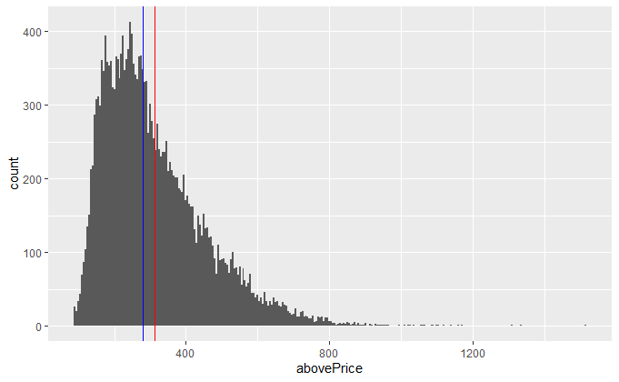

```r
# Property lot Price histogram
ggplot(data = kcre_no_waterfront) +
  geom_histogram(mapping = aes(x = abovePrice), binwidth = 5) +
  geom_vline(xintercept=mean(kcre_no_waterfront$abovePrice), color="red") +
  geom_vline(xintercept=median(kcre_no_waterfront$abovePrice), color="blue")
```

As the plots showing above, the average price are always higher than the median. And I can conclude that the real estate market is a kind of right skewed distribution in terms of unit price. And people will usually get what they paid for. So I will filter my purchasing in around the mean and average. As I can reward my purchasing with a reasonable quality and price.

Next, when purchasing a new home, everyone will like to buy a brand-new home and be the first owner. This is a common consumer psychological phenomenon. But this purchasing intention will usually beyond people’s purchasing power. But if the house is too old. It may require frequent repair or update which may lead to a non-negligible expense. To summary, instead of a new house, I will focus more on the condition of the property. To get this information I will make this data manipulation.

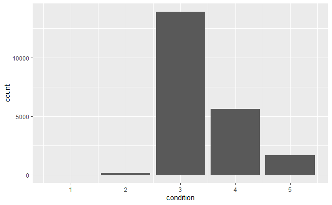

```r
# Property condition bar chart
ggplot(data = kcre_no_waterfront) +
  geom_bar(mapping = aes(x=condition))
```

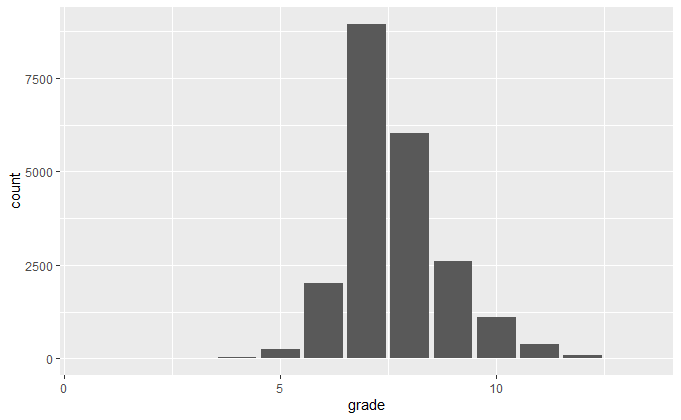

```r
# property grade bar chart
ggplot(data = kcre_no_waterfront) +
  geom_bar(mapping = aes(x=grade))
```

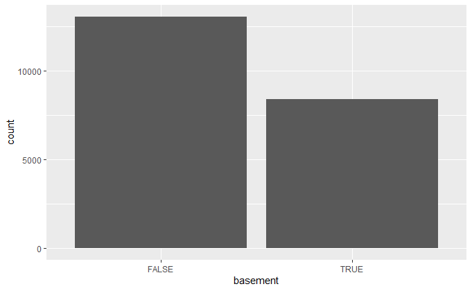

```r
# property with a basement True or False
# additional column is added to the dataset
kcre_no_waterfront <- kcre_no_waterfront %>%
  mutate(
    basement = kcre_no_waterfront$sqft_basement > 0
  )
ggplot(data = kcre_no_waterfront) +
  geom_bar(mapping = aes(x=basement))
```

As we can see, most of the properties are in condition 3 and better. So I will filter my result beyond 3. Beside, most grades are 7 or higher. So I will filter my search greater or equal to 7.

Next, I am a married man and I have a lovely baby girl. I will prefer at least 3 bedroom and 3 restrooms. I like to play rock music. I will prefer a free rock space and keep the noise in that space from neighbor and sleepy baby. So a basement works best for me. And I will filter my purchase with a True on basement.

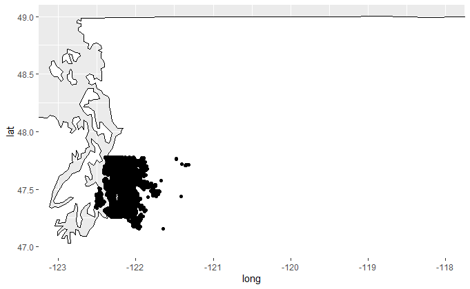

```r
usa <- map_data('usa')
properties <- tibble(
  id = kcre_no_waterfront$id,
  lat = kcre_no_waterfront$lat,
  long = kcre_no_waterfront$long,
  group = 1
)

ggplot(usa, aes(long, lat, group = group)) +
  geom_polygon(fill = "white", colour = "black") +
  coord_quickmap() +
  geom_point(data = properties, aes(x = long, y = lat)) +
  coord_cartesian(xlim=c(-123, -118), ylim = c(47, 49))
```

Now, let me try to filter my searching.

```r
prefered_property_mask <- kcre_no_waterfront$bedrooms >= 3 & kcre_no_waterfront$bathrooms >= 3
prefered_property <- kcre_no_waterfront[prefered_property_mask, ]
prefered_property <- prefered_property[prefered_property$lat > 47.5 & prefered_property$long < -122, ]
# I will start from above unit price to filter my search
prefered_property <- prefered_property[prefered_property$abovePrice >= 200 & prefered_property$abovePrice <= 400, ]
# living unit price
prefered_property <- prefered_property[prefered_property$livingPrice >= 200 & prefered_property$livingPrice <= 300, ]
# lot unit price
prefered_property <- prefered_property[prefered_property$lotPrice >= 100 & prefered_property$lotPrice <= 150, ]
# basement
prefered_property <- prefered_property[prefered_property$basement == TRUE, ]
# grade and condition
prefered_property <- prefered_property[prefered_property$grade >= 7 & prefered_property$condition >= 3, ]
# some between mean and medium
prefered_property <- prefered_property[prefered_property$price <= mean(prefered_property$price) & prefered_property$price >= median(prefered_property$price), ]
```

Now I have 12 properties satisfied my search requirement. And I believe this is a reasonable number of candidates to schedule an appointment with an agent and take a tour on site. In this assignment, I will directly choose the one with minimum price. And finally my choice is:

```r
prefered_property[which.min(prefered_property$price),]
```

| id | date | price | bedrooms | bathrooms | sqft_living | sqft_lot | floors | waterfront | view | condition | grade | sqft_above | sqft_basement | yr_built | yr_renovated | zipcode | lat | long | sqft_living15 | sqft_lot15 | lotPrice | livingPrice | abovePrice | basement |
| --- | --- | --- | --- | --- | --- | --- | --- | --- | --- | --- | --- | --- | --- | --- | --- | --- | --- | --- | --- | --- | --- | --- | --- | --- |
| 9523104345 | 2014-12-18 | 825000 | 5 | 3 | 4080 | 7500 | 2 | 0 | 2 | 4 | 8 | 2720 | 1360 | 1961 | 0 | 98103 | 47.6722 | -122.349 | 2000 | 4545 | 110 | 202.2059 | 303.3088 | TRUE |

To summary, I found the price is strong positive related with grade feature. And it is also positive related with condition feature. It is a common sense that price is positive correlated with square feet, for example living sqft, above sqft and lot sqft. Average price are always higher than the median in terms of price over many features. It indicates that the real estate market in Seattle area is a kind of right skewed distribution in terms of unit price. After considering my own needs and the market availability, I found there are 12 properties match up with my needs. Basically, I get 12 results out of 21,613 with filtering and make my decision out of 12.

Part 2 Regression

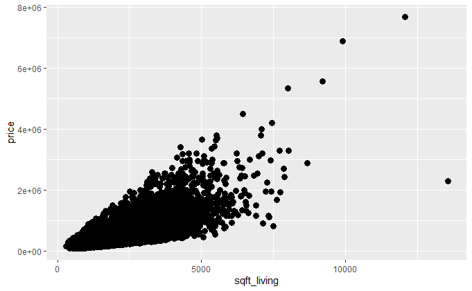

```r
# retrieve data from original dataset
sqft = kcre_no_waterfront$sqft_living
price = kcre_no_waterfront$price

ggplot(data=kcre_no_waterfront) + geom_point(aes(x=sqft_living, y=price),size=3)
```

It seems that there is certain linear relation between these two variable.

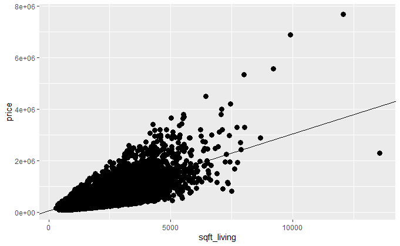

```r
# Build the model
# guess from the graph
w1 = 50000
w2 = 300

ggplot(kcre_no_waterfront, aes(sqft_living, price)) +
  geom_abline(aes(intercept = w1, slope = w2)) +
  geom_point(size=3)
```

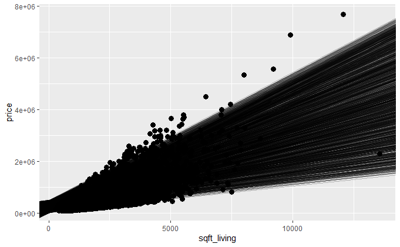

```r
num <- 2000
models <- tibble(
  w1 = runif(num, 0, 500000),
  w2 = runif(num, 100, 500)
)

ggplot(kcre_no_waterfront, aes(sqft_living, price)) +
  geom_abline(aes(intercept = w1, slope = w2), data = models, alpha = 1/4) +
  geom_point(size=3)
```

```r
NA
NA
```

```r
# (w1 and w2) and the x values and returns the y values
model1 <- function(w, data) {
  w[1] + data$sqft_living * w[2]
}
# defined (single values) w1 and w2
model1(c(w1, w2), kcre_no_waterfront)
```

```
   [1]  404000  821000  281000  638000  554000 1676000  564500  368000  584000
  [10]  617000 1118000  398000  479000  461000  593000  935000  617000  530000
  [19]  410000  425000  536000  965000  731000  371000  785000  563000  785000
  [28]  470000  506000  821000  746000  407000  749000  377000  668000  740000
  [37]  548000  758000  416000  836000  821000 1316000 1128500  521000  434000
  [46]  998000  347000  737000  425000  407000  995000  473000  644000  869000
  [55]  899000  725000  776000 1025000  605000  695000  428000  805700  512000
  [64]  548000  881000  866000  722000  350000 1010000 1481000  428000  875000
  [73]  764000  587000 1079000  578000  362000  473000 1085000  755000  620000
  [82]  656000  554000  338000  692000  848000  881000  533000  359000  644000
  [91] 1106000  410000  524000  524000 1040000  638000  398000  593000  746000
 [100]  671000  644000  707000  926000  413000  752000  551000  422000  992000
 [109]  659000  743000  428000  512000  674000 1019000 1364000  527000  314000
 [118]  521000  533000  770000  485000  281000  680000  923000  875000  680000
 [127]  698000  746000  671000  368000  653000 1235000  653000  692000  446000
```

[output cut: 98 more lines]

```r
# Distance metric ------
measure_distance <- function(w, data) {
  diff <- data$price - model1(w, data)
  # RMS
  sqrt(mean(diff ^ 2))
  # RSS
#  sum(diff^2)
}

# sample invocation
measure_distance(c(w1, w2), kcre_no_waterfront)
```

```
[1] 282706.2
```

```r
# Purrr -----
# I need a 2-parameter function for purrr -- code the function
# so that the sample dataset is used automatically (i.e.,
# the df is not a parameter of this function, but is used internally)
sim1_dist <- function(w1, w2) {
  measure_distance(c(w1, w2), kcre_no_waterfront)
}

# sample invocation - same as the measure_distance above.
sim1_dist(w1, w2)
```

```
[1] 282706.2
```

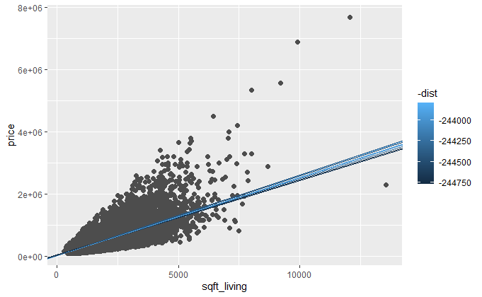

```r
# Use purrr to run the model function for each model (row)
# and store the distance in the tibble (using mutate)
models <- models %>%
  mutate(dist = purrr::map2_dbl(w1, w2, sim1_dist))

ggplot(kcre_no_waterfront, aes(sqft_living, price)) +
  geom_point(size = 2, colour = "grey30") +
  geom_abline(
    aes(intercept = w1, slope = w2, colour = -dist),
    data = filter(models, rank(dist) <= 10)
  )
```

```r
# to see the top 10
filter(models, rank(dist) <= 10)
```

| w1 | w2 | dist |
| --- | --- | --- |
| 10350.887 | 252.7284 | 243854.4 |
| 2320.527 | 259.6571 | 243798.2 |
| 7225.501 | 250.9896 | 243959.9 |
| 26889.934 | 245.4029 | 244254.1 |
| 42862.994 | 240.8112 | 244766.5 |
| 18251.899 | 250.6264 | 244004.4 |
| 10465.712 | 260.8466 | 244383.8 |
| 32921.328 | 239.9561 | 244634.3 |
| 10000.701 | 250.7320 | 243941.0 |
| 20964.793 | 255.9443 | 244513.4 |

Looks good to me. Let me do one more step to find the optimal.

```r
best <- optim(c(-500000, 0), measure_distance, data = kcre_no_waterfront)
best$par
```

```
[1] -16582.6852    264.6574
```

```r
measure_distance(c(50000, 300), kcre_no_waterfront)
```

```
[1] 282706.2
```

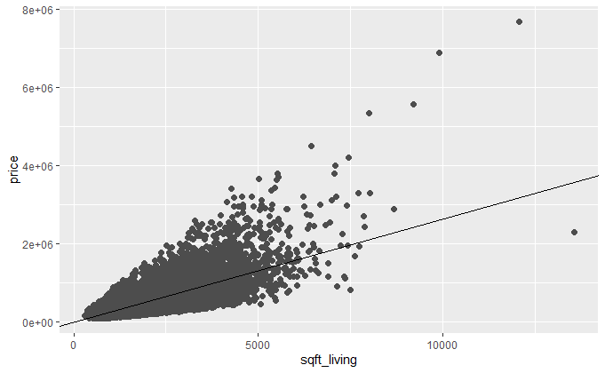

```r
# Plot the best
ggplot(kcre_no_waterfront, aes(sqft_living, price)) +
  geom_point(size = 2, colour = "grey30") +
  geom_abline(intercept = best$par[1], slope = best$par[2])
```

```r
#
# Fit the best linear model using lm()
#
m <- lm( kcre_no_waterfront$price ~ kcre_no_waterfront$sqft_living, kcre_no_waterfront)
summary(m)
```

```
Call:
lm(formula = kcre_no_waterfront$price ~ kcre_no_waterfront$sqft_living,
    data = kcre_no_waterfront)

Residuals:
     Min       1Q   Median       3Q      Max
-1286347  -141877   -23035   103771  4527927

Coefficients:
                                 Estimate Std. Error t value Pr(>|t|)
(Intercept)                    -16516.232   4150.308   -3.98 6.93e-05 ***
kcre_no_waterfront$sqft_living    264.613      1.835  144.16  < 2e-16 ***
---
Signif. codes:  0 ‘***’ 0.001 ‘**’ 0.01 ‘*’ 0.05 ‘.’ 0.1 ‘ ’ 1

Residual standard error: 243600 on 21448 degrees of freedom
Multiple R-squared:  0.4921,    Adjusted R-squared:  0.4921
F-statistic: 2.078e+04 on 1 and 21448 DF,  p-value: < 2.2e-16
```

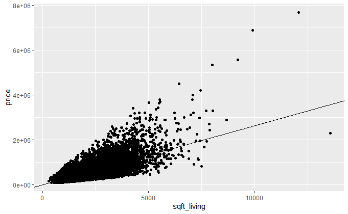

```r
# plot the scatter and regression
ggplot(data=kcre_no_waterfront) +
  geom_point(aes(x=sqft_living, y=price)) +
  geom_abline(slope=coef(m)[2], intercept=coef(m)[1])
```

```r
# Some model-related functions - Standard R lm object functions
coef(m)
```

```
                   (Intercept) kcre_no_waterfront$sqft_living
                   -16516.2315                       264.6133
```

```r
formula(m)
```

```
kcre_no_waterfront$price ~ kcre_no_waterfront$sqft_living
```